# Iris Classification

## Import Libraries:

```python
import numpy as np
import pandas as pd
import matplotlib.pyplot as plt
import seaborn as sns
from sklearn.ensemble import RandomForestClassifier
import xgboost as xgb
from sklearn.metrics import accuracy_score, classification_report, confusion_matrix
from sklearn.model_selection import cross_val_score, train_test_split, KFold, RandomizedSearchCV, GridSearchCV
import warnings
warnings.filterwarnings('ignore')
```

## Load Data

```python
url = "https://raw.githubusercontent.com/jbrownlee/Datasets/master/iris.csv"
df_iris = pd.read_csv(url, names=['sepal-length', 'sepal-width', 'petal-length', 'petal-width', 'class'])
```

## Exploratory Data Analysis:

```python
df_iris.head()
```

|  | sepal-length | sepal-width | petal-length | petal-width | class |
| --- | --- | --- | --- | --- | --- |
| 0 | 5.1 | 3.5 | 1.4 | 0.2 | Iris-setosa |
| 1 | 4.9 | 3.0 | 1.4 | 0.2 | Iris-setosa |
| 2 | 4.7 | 3.2 | 1.3 | 0.2 | Iris-setosa |
| 3 | 4.6 | 3.1 | 1.5 | 0.2 | Iris-setosa |
| 4 | 5.0 | 3.6 | 1.4 | 0.2 | Iris-setosa |

```python
df_iris.shape
```

```
(150, 5)
```

```python
df_iris.dtypes
```

```
sepal-length    float64
sepal-width     float64
petal-length    float64
petal-width     float64
class            object
dtype: object
```

```python
df_iris.isnull().sum()/len(df_iris) # No null values in any of the columns
```

```
sepal-length    0.0
sepal-width     0.0
petal-length    0.0
petal-width     0.0
class           0.0
dtype: float64
```

```python
df_iris['class'].value_counts() # Balanced data set
```

```
Iris-virginica     50
Iris-setosa        50
Iris-versicolor    50
Name: class, dtype: int64
```

```python
print("Statistical description of data:\n",df_iris.describe())
```

```
Statistical description of data:
        sepal-length  sepal-width  petal-length  petal-width
count    150.000000   150.000000    150.000000   150.000000
mean       5.843333     3.054000      3.758667     1.198667
std        0.828066     0.433594      1.764420     0.763161
min        4.300000     2.000000      1.000000     0.100000
25%        5.100000     2.800000      1.600000     0.300000
50%        5.800000     3.000000      4.350000     1.300000
75%        6.400000     3.300000      5.100000     1.800000
max        7.900000     4.400000      6.900000     2.500000
```

## Feature Distributions and Correlations:

### Observations:

1. Iris-setosa has comparatively smaller petal-length and width.
2. Petal-length and Petal-width are highly coorelated.

```python
df_iris.groupby("class").mean()
```

| class | sepal-length | sepal-width | petal-length | petal-width |
| --- | --- | --- | --- | --- |
| Iris-setosa | 5.006 | 3.418 | 1.464 | 0.244 |
| Iris-versicolor | 5.936 | 2.770 | 4.260 | 1.326 |
| Iris-virginica | 6.588 | 2.974 | 5.552 | 2.026 |

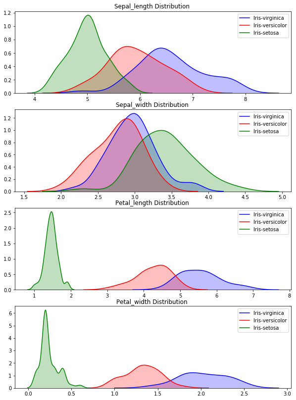

```python
fig, ax = plt.subplots(nrows=4, figsize=(10, 14))
sns.kdeplot(df_iris.loc[(df_iris['class'] == 'Iris-virginica'),'sepal-length'] , color='b',shade=True, label='Iris-virginica', ax=ax[0])
sns.kdeplot(df_iris.loc[(df_iris['class'] == 'Iris-versicolor'),'sepal-length'] , color='r',shade=True, label='Iris-versicolor', ax=ax[0])
sns.kdeplot(df_iris.loc[(df_iris['class'] == 'Iris-setosa'),'sepal-length'] , color='g',shade=True, label='Iris-setosa', ax=ax[0])
ax[0].set_title("Sepal_length Distribution ")

sns.kdeplot(df_iris.loc[(df_iris['class'] == 'Iris-virginica'),'sepal-width'] , color='b',shade=True, label='Iris-virginica', ax=ax[1])
sns.kdeplot(df_iris.loc[(df_iris['class'] == 'Iris-versicolor'),'sepal-width'] , color='r',shade=True, label='Iris-versicolor', ax=ax[1])
sns.kdeplot(df_iris.loc[(df_iris['class'] == 'Iris-setosa'),'sepal-width'] , color='g',shade=True, label='Iris-setosa', ax=ax[1])
ax[1].set_title("Sepal_width Distribution ")

sns.kdeplot(df_iris.loc[(df_iris['class'] == 'Iris-virginica'),'petal-length'] , color='b',shade=True, label='Iris-virginica', ax=ax[2])
sns.kdeplot(df_iris.loc[(df_iris['class'] == 'Iris-versicolor'),'petal-length'] , color='r',shade=True, label='Iris-versicolor', ax=ax[2])
sns.kdeplot(df_iris.loc[(df_iris['class'] == 'Iris-setosa'),'petal-length'] , color='g',shade=True, label='Iris-setosa', ax=ax[2])
ax[2].set_title("Petal_length Distribution ")

sns.kdeplot(df_iris.loc[(df_iris['class'] == 'Iris-virginica'),'petal-width'] , color='b',shade=True, label='Iris-virginica', ax=ax[3])
sns.kdeplot(df_iris.loc[(df_iris['class'] == 'Iris-versicolor'),'petal-width'] , color='r',shade=True, label='Iris-versicolor', ax=ax[3])
sns.kdeplot(df_iris.loc[(df_iris['class'] == 'Iris-setosa'),'petal-width'] , color='g',shade=True, label='Iris-setosa', ax=ax[3])
ax[3].set_title("Petal_width Distribution ");
```

|  | sepal-length | sepal-width | petal-length | petal-width |
| --- | --- | --- | --- | --- |
| sepal-length | 1.000000 | -0.109369 | 0.871754 | 0.817954 |
| sepal-width | -0.109369 | 1.000000 | -0.420516 | -0.356544 |
| petal-length | 0.871754 | -0.420516 | 1.000000 | 0.962757 |
| petal-width | 0.817954 | -0.356544 | 0.962757 | 1.000000 |

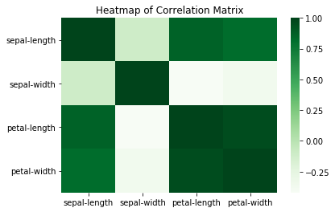

```python
# Create a correlation matrix. What features correlate the most with 'class'?
corr = df_iris.corr()
sns.heatmap(corr,
            xticklabels=corr.columns.values,
            yticklabels=corr.columns.values,
            cmap='Greens')
plt.title('Heatmap of Correlation Matrix')
corr
```

## Feature Engineering: petal_len_wid_ratio, sepal_len_wid_ratio

```python
## Since the length and width are correlated, trying transformation of features if it gives better predictions
df_iris['petal_len_wid_ratio'] = df_iris['petal-length']/df_iris['petal-width']
df_iris['sepal_len_wid_ratio'] = df_iris['sepal-length']/df_iris['sepal-width']
```

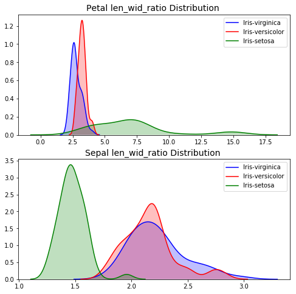

```python
fig, ax = plt.subplots(nrows=2, figsize=(8, 8))
sns.kdeplot(df_iris.loc[(df_iris['class'] == 'Iris-virginica'),'petal_len_wid_ratio'] , color='b',shade=True, label='Iris-virginica', ax=ax[0])
sns.kdeplot(df_iris.loc[(df_iris['class'] == 'Iris-versicolor'),'petal_len_wid_ratio'] , color='r',shade=True, label='Iris-versicolor', ax=ax[0])
sns.kdeplot(df_iris.loc[(df_iris['class'] == 'Iris-setosa'),'petal_len_wid_ratio'] , color='g',shade=True, label='Iris-setosa', ax=ax[0])
ax[0].set_title("Petal len_wid_ratio Distribution ", fontsize=14);

sns.kdeplot(df_iris.loc[(df_iris['class'] == 'Iris-virginica'),'sepal_len_wid_ratio'] , color='b',shade=True, label='Iris-virginica', ax=ax[1])
sns.kdeplot(df_iris.loc[(df_iris['class'] == 'Iris-versicolor'),'sepal_len_wid_ratio'] , color='r',shade=True, label='Iris-versicolor', ax=ax[1])
sns.kdeplot(df_iris.loc[(df_iris['class'] == 'Iris-setosa'),'sepal_len_wid_ratio'] , color='g',shade=True, label='Iris-setosa', ax=ax[1])
ax[1].set_title("Sepal len_wid_ratio Distribution ", fontsize=14);
```

## Creating 2 different training and test data sets with different feature variables

```python
X_1 = df_iris.drop(columns=['petal_len_wid_ratio', 'sepal_len_wid_ratio', 'class'])
Y_1 = df_iris['class']
X_train_1, X_test_1, Y_train_1, Y_test_1 = train_test_split(X_1, Y_1, test_size=0.2, random_state=20)
```

```python
X_2 = df_iris[['petal_len_wid_ratio', 'sepal_len_wid_ratio']]
Y_2 = df_iris['class']
X_train_2, X_test_2, Y_train_2, Y_test_2 = train_test_split(X_2, Y_2, test_size=0.2, random_state=20)
```

## Training Models:

```python
seed = 7
models = []
models.append(('RF', RandomForestClassifier(random_state=seed)))
models.append(('GB', xgb.XGBClassifier(random_state=seed)))
```

```python
# Test options and evaluation metric
scoring = 'accuracy'

results = []
names = []

def eval_model(X_test, Y_test, model):
    kfold = KFold(random_state=seed, n_splits=10)
    res = cross_val_score(model, X_test, Y_test, cv=kfold, scoring=scoring)
    return res

# evaluate each model in turn
print("Model with original feature varibles:\n")
for name, model in models:
    res = eval_model(X_train_1, Y_train_1, model)
    results.append(res)
    names.append(name)
    msg = "%s: %f (%f)" % (name, res.mean(), res.std())
    print(msg)

print("\nModel with feature engineered varibles:\n")
for name, model in models:
    res = eval_model(X_train_2, Y_train_2, model)
    results.append(res)
    names.append(name)
    msg = "%s: %f (%f)" % (name, res.mean(), res.std())
    print(msg)
```

```
Model with original feature varibles:

RF: 0.966667 (0.055277)
GB: 0.950000 (0.055277)

Model with feature engineered varibles:

RF: 0.850000 (0.081650)
GB: 0.841667 (0.108333)
```

Model with feature engineered variables does not perform well in terms of accuracy. So, I continue with original variables.

## Base Line Random Forest Classifier:

```python
# Base line Random Forest model
rf = RandomForestClassifier(random_state=seed)
rf.fit(X_train_1, Y_train_1)
rf_test_pred = rf.predict(X_test_1)
print("Base-line Model | Accuracy on test data set:%.5f" %accuracy_score(Y_test_1, rf_test_pred))
```

```
Base-line Model | Accuracy on test data set:0.90000
```

## Random Search for best hyper-parameters:

```python
# Number of trees in random forest
n_estimators = [int(x) for x in np.linspace(start = 200, stop = 2000, num = 10)]
# Number of features to consider at every split
max_features = ['auto', 'sqrt']
# Maximum number of levels in tree
max_depth = [int(x) for x in np.linspace(10, 110, num = 11)]
max_depth.append(None)
# Minimum number of samples required to split a node
min_samples_split = [2, 5, 10]
# Minimum number of samples required at each leaf node
min_samples_leaf = [1, 2, 4]
# Method of selecting samples for training each tree
bootstrap = [True, False]

# Create the random grid
random_grid = {'n_estimators': n_estimators,
               'max_features': max_features,
               'max_depth': max_depth,
               'min_samples_split': min_samples_split,
               'min_samples_leaf': min_samples_leaf,
               'bootstrap': bootstrap}
```

```python
# Random search of parameters, using 3 fold cross validation,
# search across 100 different combinations, and use all available cores
rf_random = RandomizedSearchCV(estimator = rf, param_distributions = random_grid, n_iter = 100, cv = 3, verbose=2, random_state=seed, n_jobs = -1)
# Fit the random search model
rf_random.fit(X_train_1, Y_train_1)
```

```
Fitting 3 folds for each of 100 candidates, totalling 300 fits
```

```
[Parallel(n_jobs=-1)]: Done  25 tasks      | elapsed:   22.4s
[Parallel(n_jobs=-1)]: Done 146 tasks      | elapsed:  1.3min
[Parallel(n_jobs=-1)]: Done 300 out of 300 | elapsed:  2.6min finished
```

```
RandomizedSearchCV(cv=3, error_score='raise',
          estimator=RandomForestClassifier(bootstrap=True, class_weight=None, criterion='gini',
            max_depth=None, max_features='auto', max_leaf_nodes=None,
            min_impurity_decrease=0.0, min_impurity_split=None,
            min_samples_leaf=1, min_samples_split=2,
            min_weight_fraction_leaf=0.0, n_estimators=10, n_jobs=1,
            oob_score=False, random_state=7, verbose=0, warm_start=False),
          fit_params=None, iid=True, n_iter=100, n_jobs=-1,
          param_distributions={'n_estimators': [200, 400, 600, 800, 1000, 1200, 1400, 1600, 1800, 2000], 'max_features': ['auto', 'sqrt'], 'max_depth': [10, 20, 30, 40, 50, 60, 70, 80, 90, 100, 110, None], 'min_samples_split': [2, 5, 10], 'min_samples_leaf': [1, 2, 4], 'bootstrap': [True, False]},
          pre_dispatch='2*n_jobs', random_state=7, refit=True,
          return_train_score='warn', scoring=None, verbose=2)
```

```python
rf_random.best_params_
```

```
{'n_estimators': 1400,
 'min_samples_split': 2,
 'min_samples_leaf': 4,
 'max_features': 'auto',
 'max_depth': 100,
 'bootstrap': True}
```

```python
best_random = rf_random.best_estimator_
rf_random_test_pred = best_random.predict(X_test_1)
print("RandomizedSearchCV: RandomForest | Accuracy on test data set:%.5f" %accuracy_score(Y_test_1, rf_random_test_pred))
```

```
RandomizedSearchCV: RandomForest | Accuracy on test data set:0.90000
```

There is no improvement on test accuracy with this set of hyper parameters.

## Grid Search for best hyper-parameters:

Now, I conduct focussed search, I explicitly specify every combination of settings to try. I do this with GridSearchCV, a method that, instead of sampling randomly from a distribution, evaluates all combinations that are defined. To use Grid Search, I make another grid based on the best values provided by random search:

```python
# Create the parameter grid based on the results of random search
# Number of trees in random forest
n_estimators = [1250, 1300, 1350, 1400]
# Number of features to consider at every split
max_features = ['auto']
# Maximum number of levels in tree
max_depth =[100, 110, 120]
max_depth.append(None)
# Minimum number of samples required to split a node
min_samples_split = [2, 3]
# Minimum number of samples required at each leaf node
min_samples_leaf = [3, 4, 5]
# Method of selecting samples for training each tree
bootstrap = [True]
param_grid = {
    'bootstrap':bootstrap ,
    'max_depth':max_depth ,
    'max_features':max_features ,
    'min_samples_leaf':min_samples_leaf ,
    'min_samples_split':min_samples_split ,
    'n_estimators': n_estimators
}
# Instantiate the grid search model
grid_search = GridSearchCV(estimator = rf, param_grid = param_grid,
                          cv = 3, n_jobs = -1, verbose = 2)
```

```python
# Fit the grid search to the data
grid_search.fit(X_train_1, Y_train_1)
grid_search.best_params_
```

```
Fitting 3 folds for each of 96 candidates, totalling 288 fits
```

```
[Parallel(n_jobs=-1)]: Done  25 tasks      | elapsed:   24.8s
[Parallel(n_jobs=-1)]: Done 146 tasks      | elapsed:  1.6min
[Parallel(n_jobs=-1)]: Done 288 out of 288 | elapsed:  2.9min finished
```

```
{'bootstrap': True,
 'max_depth': 100,
 'max_features': 'auto',
 'min_samples_leaf': 4,
 'min_samples_split': 2,
 'n_estimators': 1250}
```

```python
best_grid = grid_search.best_estimator_
rf_grid_test_pred = best_grid.predict(X_test_1)
print("GridSearchCV: RandomForest | Accuracy on test data set:%.5f" %accuracy_score(Y_test_1, rf_grid_test_pred))
```

```
GridSearchCV: RandomForest | Accuracy on test data set:0.90000
```

Accuracy scores did not improve, so I use the base random forest model.

```python
print("Random Forest:\n")
print(confusion_matrix(Y_test_1, rf.predict(X_test_1)))
print(classification_report(Y_test_1, rf.predict(X_test_1)))
```

```
Random Forest:

[[ 8  0  0]
 [ 0 11  0]
 [ 0  3  8]]
                 precision    recall  f1-score   support

    Iris-setosa       1.00      1.00      1.00         8
Iris-versicolor       0.79      1.00      0.88        11
 Iris-virginica       1.00      0.73      0.84        11

    avg / total       0.92      0.90      0.90        30
```

## Feature Importance:

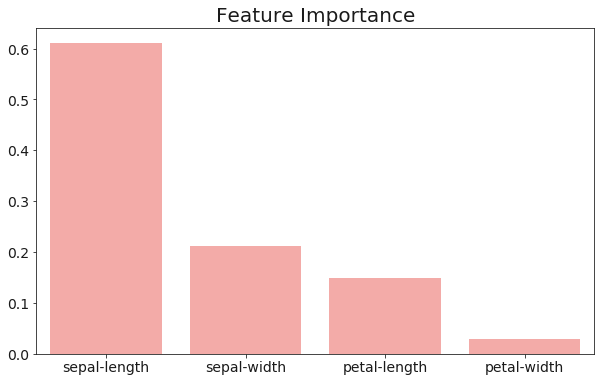

```python
plt.figure(figsize=(10, 6))
feature_importances = pd.Series(rf.feature_importances_, index=X_1.columns)
feature_importances.sort_values(inplace=True, ascending=False)
sns.set_color_codes("pastel")
sns.barplot(x=X_1.columns, y=feature_importances, color="r")
plt.xticks(size=14)
plt.yticks(size=14)
plt.title("Feature Importance", size=20);
```

## XGBoost Model

```python
# Examine the default parameters
xgb.XGBClassifier()
```

```
XGBClassifier(base_score=0.5, booster='gbtree', colsample_bylevel=1,
       colsample_bytree=1, gamma=0, learning_rate=0.1, max_delta_step=0,
       max_depth=3, min_child_weight=1, missing=None, n_estimators=100,
       n_jobs=1, nthread=None, objective='binary:logistic', random_state=0,
       reg_alpha=0, reg_lambda=1, scale_pos_weight=1, seed=None,
       silent=True, subsample=1)
```

## XGBoost Model with default parameters:

```python
gb = xgb.XGBClassifier(random_state=seed)
gb.fit(X_train_1, Y_train_1)
print("XGBoost Model | Accuracy on test data set:%.5f" %accuracy_score(Y_test_1, gb.predict(X_test_1)))
```

```
XGBoost Model | Accuracy on test data set:0.93333
```

## Hyper-Parameter Tuning: Grid Search

```python
# Define Parameters
model = xgb.XGBClassifier()
param_grid = {"max_depth": [2,3,10],
              "n_estimators": [50,100,200],
              "learning_rate": [0.05,0.1,0.02,0.2]}

# Perform Grid Search CV
gb_cv = GridSearchCV(model, param_grid=param_grid, cv = 3)
```

```python
gb_cv.fit(X_train_1, Y_train_1)
```

```
GridSearchCV(cv=3, error_score='raise',
       estimator=XGBClassifier(base_score=0.5, booster='gbtree', colsample_bylevel=1,
       colsample_bytree=1, gamma=0, learning_rate=0.1, max_delta_step=0,
       max_depth=3, min_child_weight=1, missing=None, n_estimators=100,
       n_jobs=1, nthread=None, objective='binary:logistic', random_state=0,
       reg_alpha=0, reg_lambda=1, scale_pos_weight=1, seed=None,
       silent=True, subsample=1),
       fit_params=None, iid=True, n_jobs=1,
       param_grid={'max_depth': [2, 3, 10], 'n_estimators': [50, 100, 200], 'learning_rate': [0.05, 0.1, 0.02, 0.2]},
       pre_dispatch='2*n_jobs', refit=True, return_train_score='warn',
       scoring=None, verbose=0)
```

```python
# Best hyperparmeter setting
gb_best = gb_cv.best_estimator_
print("XGBoost Model-grid search | Accuracy on test data set:%.5f" %accuracy_score(Y_test_1, gb_best.predict(X_test_1)))
```

```
XGBoost Model-grid search | Accuracy on test data set:0.90000
```

Accuracy score on test data of this model is less than the model with default parameters. So, I use the model with default parameters.

## Early Stopping

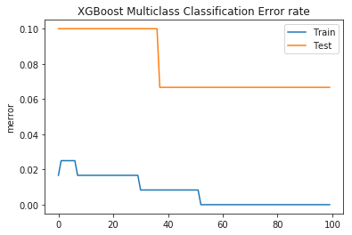

```python
# Create eval_set
eval_set = [(X_train_1, Y_train_1), (X_test_1, Y_test_1)]

# Fit our model to the training set
gb.fit(X_train_1, Y_train_1, eval_set=eval_set, verbose=False)

# Make predictions with test data
Y_pred = gb.predict(X_test_1)

# Retrieve performance metrics
results = gb.evals_result()
epochs = len(results['validation_0']['merror'])
x_axis = range(0, epochs)

# Plot log loss curve
fig, ax = plt.subplots()
ax.plot(x_axis, results['validation_0']['merror'], label='Train')
ax.plot(x_axis, results['validation_1']['merror'], label='Test')
ax.legend()
plt.ylabel('merror')
plt.title('XGBoost Multiclass Classification Error rate');
```

## Feature Importance

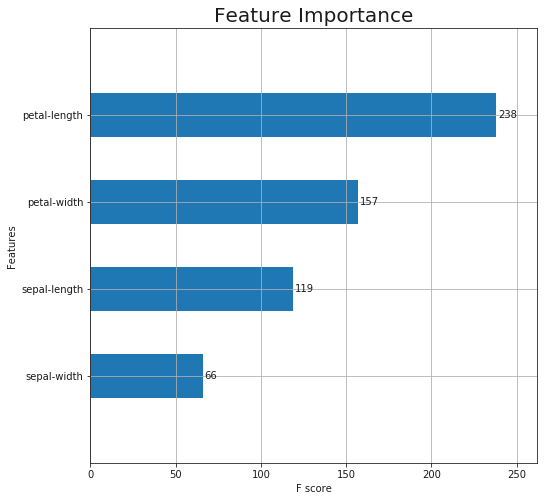

```python
# Plot basic feature importance chart
fig, ax = plt.subplots(figsize=(8,8))
xgb.plot_importance(gb, height=0.5, ax=ax)
plt.title("Feature Importance", size=20);
```

## Appendix

### XGBoost Parameters

**Important Parameters for Overfitting:**

- **learning_rate**: Controls the contribution of each tree in the ensemble (optimal values between 0.01-0.2). ESL states that the best strategy might be to set learning_rate low (<0.1) and then choose n_estimators by early stopping.
- **max_depth**: Controls the depth of the tree. More depth = more complexity, more variance, and slower computation speed. (Optimal values between 4-8)
- **min_child_weight**: (default is 1)
- **gamma**: it's an additional regularization parameter (similar to learning_rate)

**Import Parameters for Speed/Computation:**

- **colsample_bytree**: subsample ratio of column (features) - Randomness; better generalizability
- **subsample**: subsample ratio of training instances (observations) - Randomness; better generalizability
- **n_estimators**: number of boosting trees

### Examining the affect of each hyper-parameter individually

```python
eval_set = [(X_train_1, Y_train_1), (X_test_1, Y_test_1)]
```

```python
res = []
# Examining max depth parameter
max_depth_list = [2,3,4,5,10,12,15]
for depth in max_depth_list:
    clf = xgb.XGBClassifier(max_depth=depth, random_state=seed)
    clf.fit(X_train_1, Y_train_1, eval_set=eval_set, verbose=False)
    res.append(
        {
            'max_depth': depth,
            'train_error': accuracy_score(Y_train_1, clf.predict(X_train_1)),
            'test_error': accuracy_score(Y_test_1, clf.predict(X_test_1))
        })
```

```python
# Display Results
max_depth_lr = pd.DataFrame(res).set_index('max_depth').sort_index()
max_depth_lr
```

| max_depth | test_error | train_error |
| --- | --- | --- |
| 2 | 0.900000 | 1.0 |
| 3 | 0.933333 | 1.0 |
| 4 | 0.933333 | 1.0 |
| 5 | 0.933333 | 1.0 |
| 10 | 0.933333 | 1.0 |
| 12 | 0.933333 | 1.0 |
| 15 | 0.933333 | 1.0 |

Looks like the best max_depth is 3

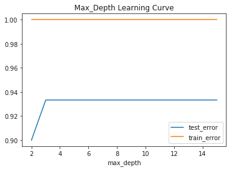

```python
# Plot Max_Depth Learning Curve
max_depth_lr.plot(title="Max_Depth Learning Curve")
```

```python
### Examining the learning rate parameter
res = []
for learning_rate in [0.05,0.1,0.2,0.4,0.6,0.8,1]:
    clf = xgb.XGBClassifier(max_depth=3,learning_rate=learning_rate, n_estimators=200)
    clf.fit(X_train_1, Y_train_1, eval_set=eval_set, verbose=False)
    res.append(
        {
            'learning_rate': learning_rate,
            'train_error': accuracy_score(Y_train_1, clf.predict(X_train_1)),
            'test_error': accuracy_score(Y_test_1, clf.predict(X_test_1))
        })

learning_rate_lr = pd.DataFrame(res).set_index('learning_rate').sort_index()
learning_rate_lr
```

| learning_rate | test_error | train_error |
| --- | --- | --- |
| 0.05 | 0.933333 | 1.0 |
| 0.10 | 0.933333 | 1.0 |
| 0.20 | 0.900000 | 1.0 |
| 0.40 | 0.900000 | 1.0 |
| 0.60 | 0.900000 | 1.0 |
| 0.80 | 0.900000 | 1.0 |
| 1.00 | 0.900000 | 1.0 |

The best learning rate is 0.05.

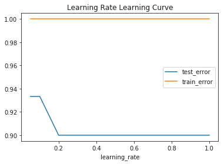

```python
# Plot Learning Rate
learning_rate_lr.plot(title="Learning Rate Learning Curve")
```

```python
# Examining N_Estimators Parameter
results = []

for n_estimators in [10,50,60,100,150,200,500,750,1000, 1500]:
    clf = xgb.XGBClassifier(max_depth=3,learning_rate=0.05, n_estimators=n_estimators)
    clf.fit(X_train_1, Y_train_1, eval_set=eval_set, verbose=False)
    results.append(
        {
            'n_estimators': n_estimators,
            'train_error': accuracy_score(Y_train_1, clf.predict(X_train_1)),
            'test_error': accuracy_score(Y_test_1, clf.predict(X_test_1))
        })

n_estimators_lr = pd.DataFrame(results).set_index('n_estimators').sort_index()
n_estimators_lr
```

| n_estimators | test_error | train_error |
| --- | --- | --- |
| 10 | 0.900000 | 0.975000 |
| 50 | 0.900000 | 0.983333 |
| 60 | 0.900000 | 0.983333 |
| 100 | 0.933333 | 0.991667 |
| 150 | 0.933333 | 1.000000 |
| 200 | 0.933333 | 1.000000 |
| 500 | 0.933333 | 1.000000 |
| 750 | 0.900000 | 1.000000 |
| 1000 | 0.900000 | 1.000000 |
| 1500 | 0.900000 | 1.000000 |

N_estimators:100 seems the right value.

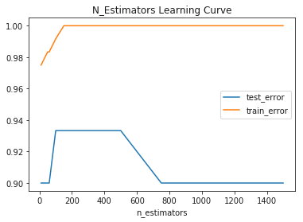

```python
## Plotting the learning curve
n_estimators_lr.plot(title="N_Estimators Learning Curve")
```